# Homework 3

Author

1. Load the `{tidyverse}`, `{ggridges}`, and `{ISLR}` packages in the “setup” chunk. (Install any if needed.)
2. Run the following lines of code to read about and view the data we’ll use for this lab.
- Comment out line 32 after you run it, but putting a `#` at the start of the line.

```r
str(gss_cat)
#View(gss_cat)
#?gss_cat
```

3. Use `{ggplot2}` to create a histogram of `tvhours`. The plot should:
- Include a small amount of transparency so grid lines are visible under the histogram.
- Be a different color than the default
- Include meaningful axis labels
- Have a title and a subtitle

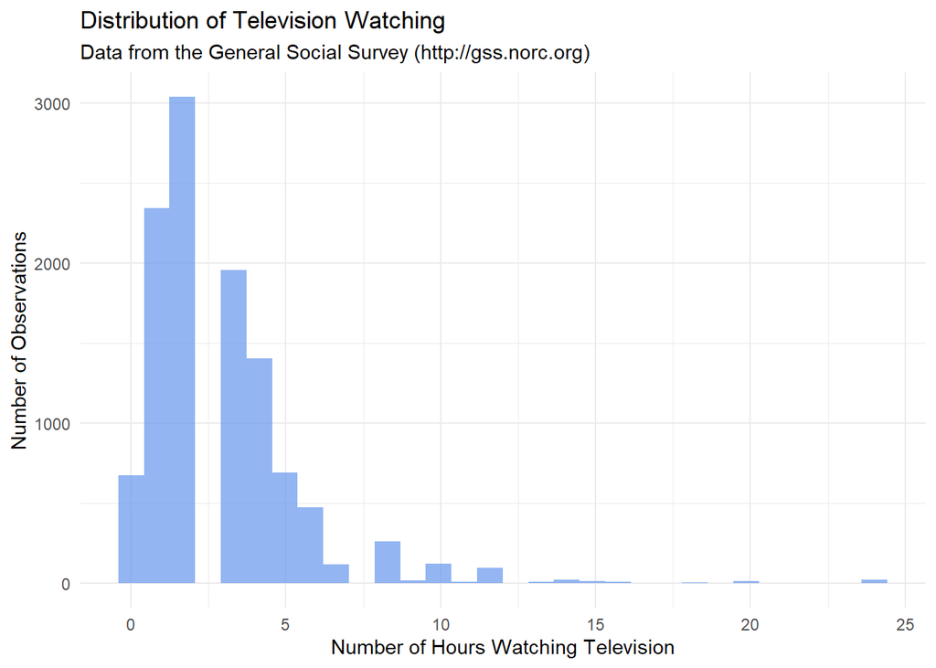

```r
theme_set(theme_minimal())

gss_cat |>
  ggplot(aes(tvhours)) +
  geom_histogram(fill = "cornflowerblue",
                 alpha = 0.7) +
  labs(x = "Number of Hours Watching Television",
       y = "Number of Observations",
       title = "Distribution of Television Watching",
       subtitle = "Data from the General Social Survey (http://gss.norc.org)")
```

4. Create a ridgeline density plot of `age` by `partyid`. Do you notice any strong differences by party affiliation?

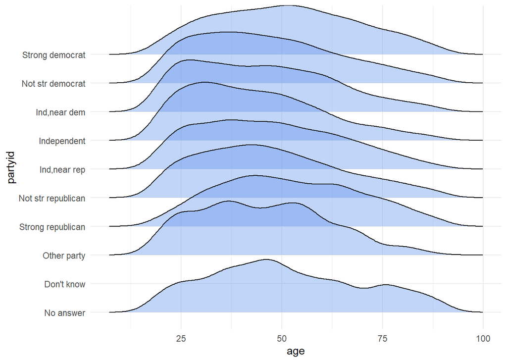

```r
gss_cat |>
  ggplot(aes(age, partyid)) +
  geom_density_ridges(fill = "cornflowerblue", alpha = 0.4)
```

5. Modify the plot from Question 4 to produce separate ridgeline densities by `race` within one plot. Do you see any patterns?

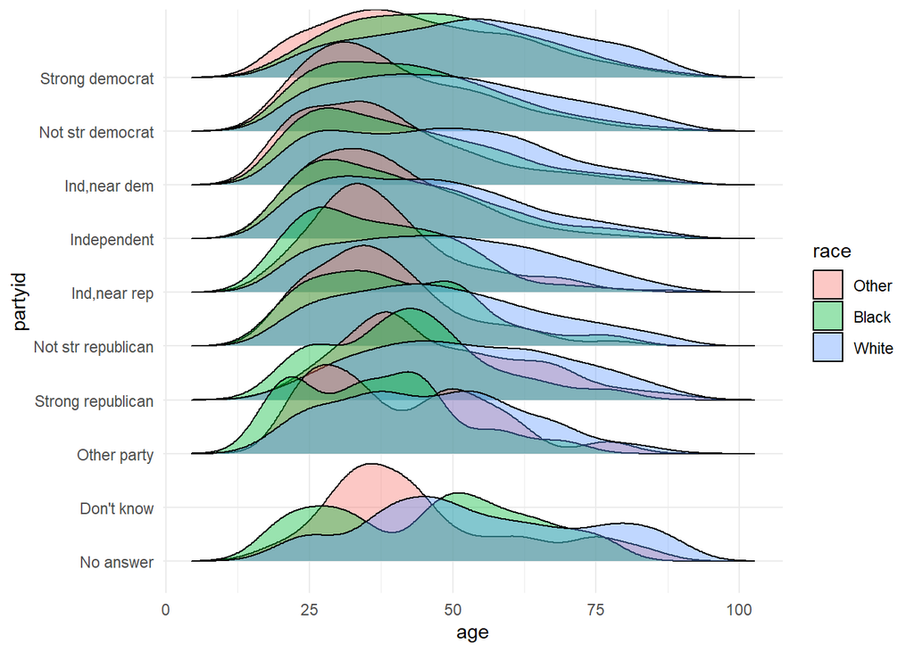

```r
gss_cat |>
  ggplot(aes(age, partyid)) +
  geom_density_ridges(aes(fill = race), alpha = 0.4)
```

6. Replicate the plots from Questions 4 and 5, but this time displaying the relations with boxplots (i.e., one boxplot from Question 4 and one boxplot for Question 5 in the chunk below). Try using `coord_flip`. Which do you think displays the relation more clearly? Why?

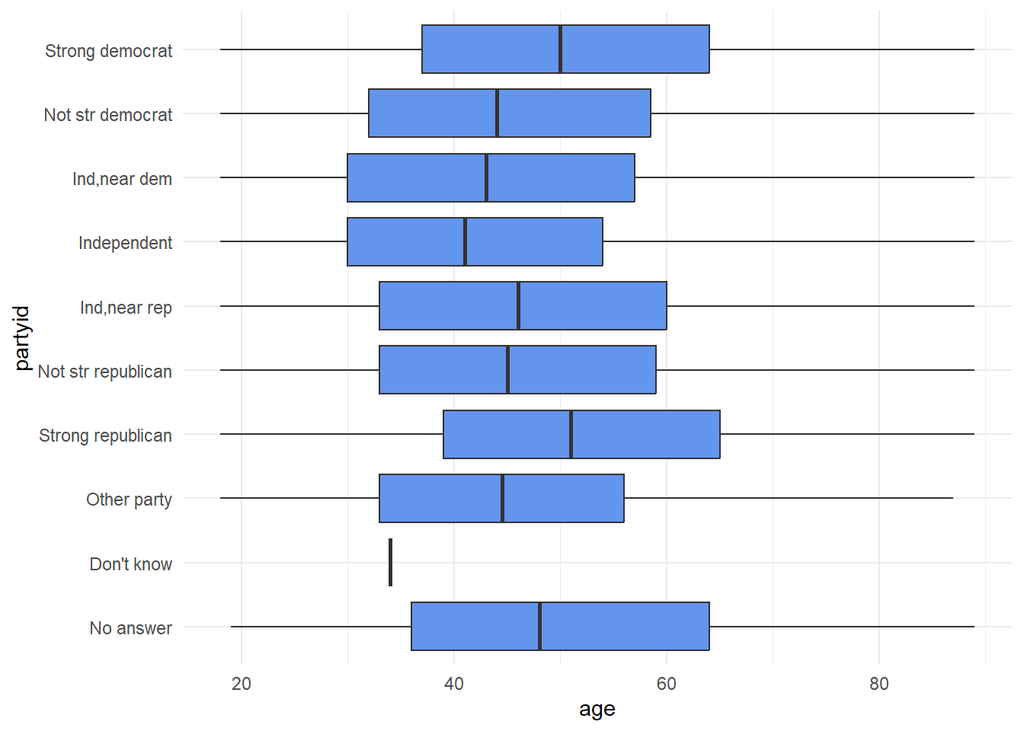

```r
gss_cat |>
  ggplot(aes(partyid, age)) +
  geom_boxplot(fill = "cornflowerblue") +
  coord_flip()
```

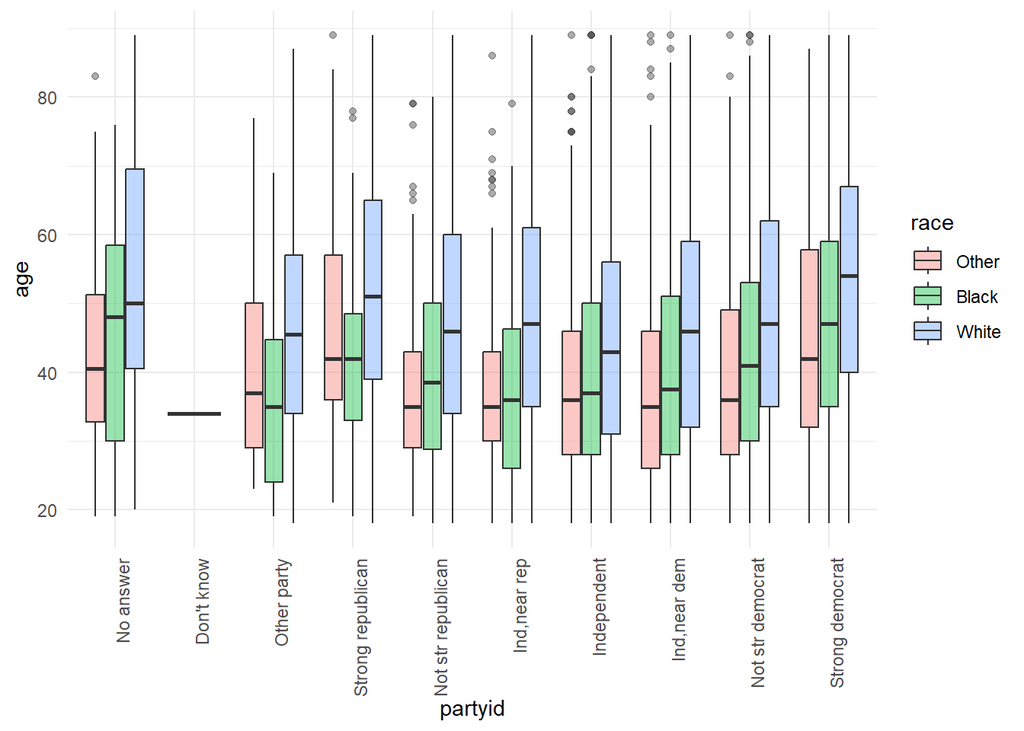

```r
gss_cat |>
  ggplot(aes(partyid, age)) +
  geom_boxplot(aes(fill = race), alpha = 0.4) +
  theme(axis.text.x = element_text(angle = 90, hjust = 1))
```

7. Run the following lines of code to get a correlation table as a data frame.

```r
cor_tbl <- Hitters |>
  select_if(is.numeric) |>
  cor(use = "pairwise.complete.obs") |>
  as.data.frame() |>
  mutate(row = row.names(.)) |>
  gather(col, cor, -row) |>
  tbl_df()
```

```
Error:
! `tbl_df()` was deprecated in dplyr 1.0.0 and is now defunct.
ℹ Please use `tibble::as_tibble()` instead.
```

Use the correlation table to create a heatmap using `geom_tile`. Change the colors to one of the four `viridis` palettes. What does the heatmap help you see?

```r
cor_tbl |>
  ggplot(aes(row, col, fill = cor)) +
  geom_tile() +
  scale_fill_viridis_c(option = "inferno") +
  theme(axis.text.x = element_text(angle = 90, hjust = 1))
```

[output not shown]

```
Error:
! object 'cor_tbl' not found
```